# FE Compass

Hubert Baniecki, Łukasz Brzozowski, Szymon Maksymiuk

02.04.2019

# 1 Model początkowy

Używamy modelu klasyfikacyjnego `classif.ranger` z pakietu `mlr`, który używa metody lasów losowych.

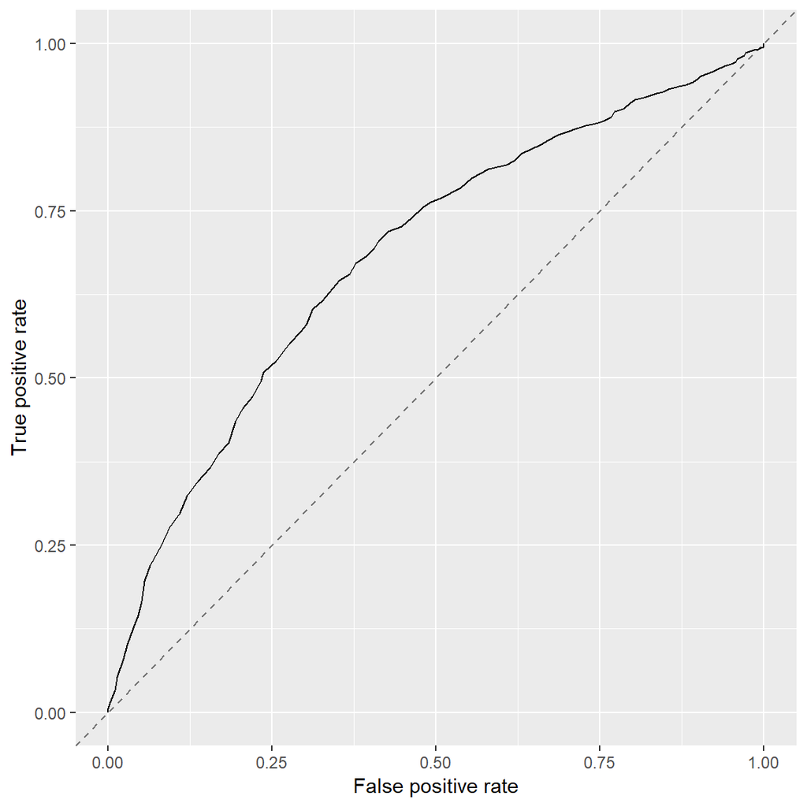

```r
set.seed(1231)
tempTrain <- select(train, -jailLength, -juvSum)
tempTest <- select(test, -jailLength, -juvSum)
classifTask <- makeClassifTask(data = tempTrain, target = "isRecid")
Lrn <- makeLearner("classif.ranger", predict.type = "prob")
r <- mlr::train(Lrn, classifTask)
results <- predict(r, newdata = tempTest)
temp <-  generateThreshVsPerfData(results, measures = list(fpr, tpr, mmce))
plotROCCurves(temp)
```

```r
performance(results, list(auc,acc))
```

```
##       auc       acc
## 0.6837689 0.6708108
```

# 2 Modyfikacje danych

## 2.1 Dataset bez kolumny `chargeDesc`

```r
set.seed(1231)
tempTrain <- select(tempTrain, -chargeDesc)
tempTest <- select(tempTest, - chargeDesc)
classifTask <- makeClassifTask(data = tempTrain, target = "isRecid")
Lrn <- makeLearner("classif.ranger", predict.type = "prob")
r <- mlr::train(Lrn, classifTask)
results <- predict(r, newdata = tempTest)
performance(results, list(auc,acc))
```

```
##       auc       acc
## 0.7017382 0.6908108
```

Widzimy, że zmienna `chargeDesc` w niezmienionej formie mogła zaszumiać dane i utrudniać klasyfikację.

## 2.2 Dodanie kolumny `juvSum` i `jailLength`

```r
set.seed(1231)
tempDat <- select(df, -c(juvFel, juvMisd, juvOther, chargeDesc))
m <- sample(7850, 6000)
tempTrain <- tempDat[m,]
tempTest <- tempDat[-m,]

head(tempTrain)
```

|  | sex | age | ageCat | race | priors | chargeDegree | isRecid | jailLength | juvSum |
| --- | --- | --- | --- | --- | --- | --- | --- | --- | --- |
| 3674 | Male | 52 | Greater than 45 | Caucasian | 1 | (F3) | 0 | 1 | 0 |
| 60 | Male | 49 | Greater than 45 | African-American | 4 | (M1) | 0 | 1 | 0 |
| 5938 | Male | 26 | 25 - 45 | Caucasian | 10 | (F3) | 1 | 1 | 0 |
| 1668 | Male | 21 | Less than 25 | African-American | 2 | (MO3) | 0 | 249 | 0 |
| 308 | Male | 46 | Greater than 45 | Caucasian | 3 | (F3) | 0 | 14 | 0 |
| 2413 | Male | 36 | 25 - 45 | African-American | 3 | (M1) | 1 | 2 | 0 |

```r
classifTask <- makeClassifTask(data = tempTrain, target = "isRecid")
Lrn <- makeLearner("classif.ranger", predict.type = "prob")
r <- mlr::train(Lrn, classifTask)
results <- predict(r, newdata = tempTest)
performance(results, list(auc,acc))
```

```
##       auc       acc
## 0.7398756 0.7113514
```

Wyniki modelu trochę się poprawiły. Co można jeszcze zrobić?

## 2.3 Iloczyn kolumn kategorycznych

```r
set.seed(1231)
df2 <- df %>% select(-c(juvFel, juvMisd, juvOther, chargeDesc)) %>%
                  mutate(sexAgeCat = as.factor(paste(sex,ageCat)),
                    sexRace = as.factor(paste(sex,race)),
                    ageCatRace = as.factor(paste(ageCat,race)))
m <- sample(7850, 6000)
tempTrain <- df2[m,]
tempTest <- df2[-m,]

head(select(df2, sexAgeCat, sexRace, ageCatRace))
```

|  | sexAgeCat | sexRace | ageCatRace |
| --- | --- | --- | --- |
| 1 | Male Greater than 45 | Male Other | Greater than 45 Other |
| 2 | Male 25 - 45 | Male African-American | 25 - 45 African-American |
| 3 | Male Less than 25 | Male African-American | Less than 25 African-American |
| 4 | Male 25 - 45 | Male Other | 25 - 45 Other |
| 5 | Male 25 - 45 | Male Caucasian | 25 - 45 Caucasian |
| 6 | Male 25 - 45 | Male Other | 25 - 45 Other |

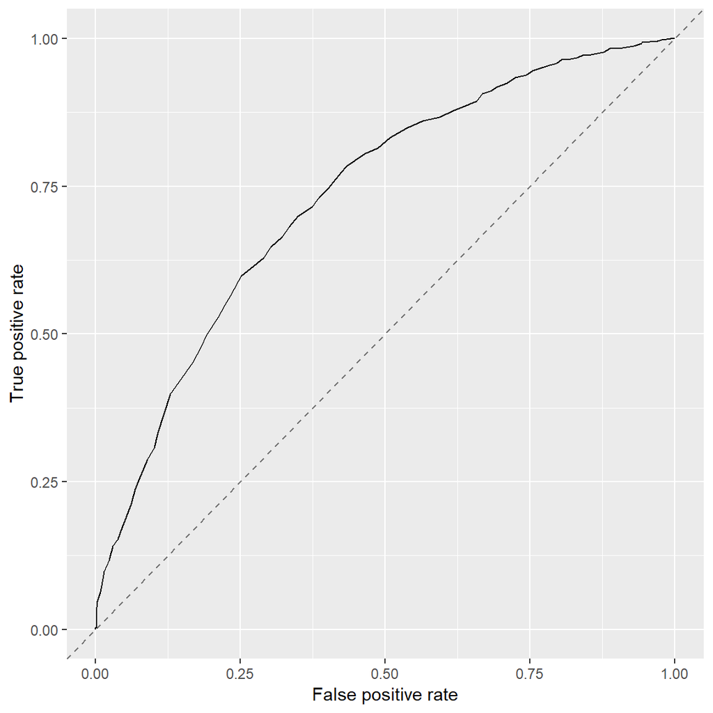

```r
classifTask <- makeClassifTask(data = tempTrain, target = "isRecid")
Lrn <- makeLearner("classif.ranger", predict.type = "prob")
r <- mlr::train(Lrn, classifTask)
results <- predict(r, newdata = tempTest)
temp <-  generateThreshVsPerfData(results, measures = list(fpr, tpr, mmce))
plotROCCurves(temp)
```

```r
performance(results, list(auc,acc))
```

```
##       auc       acc
## 0.7329438 0.7059459
```

# 3 Kodowanie

## 3.1 Dyskretyzacja zmiennych `priors`, `jailLength` i `juvSum`

Dyskretyzacja zmiennych nie pomogła, ale dodatkowe kolumny mogłyby zapunktować w boostingu.

```r
set.seed(12)
df3 <- df2 %>% mutate(dtJuvSum = discretize(df$juvSum, method="cluster"),
                    dtPriors = discretize(df$priors, method = "cluster"),
                    dtJailLength = discretize(df$jailLength, method = "cluster"))

head(select(df3, dtJuvSum, dtPriors, dtJailLength))
```

|  | dtJuvSum | dtPriors | dtJailLength |
| --- | --- | --- | --- |
| 1 | [0,0.722) | [0,3.67) | [1,97.9) |
| 2 | [0,0.722) | [0,3.67) | [1,97.9) |
| 3 | [0.722,3.61) | [3.67,11.7) | [1,97.9) |
| 4 | [0,0.722) | [0,3.67) | [1,97.9) |
| 5 | [0,0.722) | [11.7,38] | [1,97.9) |
| 6 | [0,0.722) | [0,3.67) | [1,97.9) |

```r
m <- sample(7850, 6000)
tempTrain <- df3[m,]
tempTest <- df3[-m,]

classifTask <- makeClassifTask(data = tempTrain, target = "isRecid")
Lrn <- makeLearner("classif.ranger", predict.type = "prob")
r <- mlr::train(Lrn, classifTask)
results <- predict(r, newdata = tempTest)
performance(results, list(auc,acc))
```

```
##       auc       acc
## 0.6972834 0.6962162
```

## 3.2 ImpactEncoding

Nic nie pomógł.

```r
set.seed(1234)
cC <- mkCrossFrameCExperiment(df3,varlist = c("sex","ageCat","race","chargeDegree","sexAgeCat",
                       "sexRace","ageCatRace","dtJuvSum","dtPriors","dtJailLength"),
                              outcomename = "isRecid", outcometarget = 1)
```

```
## [1] "vtreat 1.3.7 start initial treatment design Tue Apr 02 15:43:42 2019"
## [1] " start cross frame work Tue Apr 02 15:43:54 2019"
## [1] " vtreat::mkCrossFrameCExperiment done Tue Apr 02 15:44:00 2019"
```

```r
treatment <- cC$treatments
vars <- treatment$scoreFrame$varName[treatment$scoreFrame$code %in% c("catB")]

extra <- setdiff(colnames(tempTrain), c("sex","ageCat","race","chargeDegree","sexAgeCat",
                   "sexRace","ageCatRace","dtJuvSum","dtPriors","dtJailLength", "isRecid"))
trainTreated <- vtreat::prepare(treatment,tempTrain,extracols = extra, varRestriction = vars)
testTreated <- vtreat::prepare(treatment,tempTest,extracols = extra, varRestriction = vars)

head(trainTreated)
```

|  | ageCat_catB | race_catB | chargeDegree_catB | sexAgeCat_catB | sexRace_catB | ageCatRace_catB | dtJuvSum_catB | dtPriors_catB | dtJailLength_catB | isRecid | age | priors | jailLength | juvSum |
| --- | --- | --- | --- | --- | --- | --- | --- | --- | --- | --- | --- | --- | --- | --- |
| 1 | 0.02281675 | 0.2564117 | -0.2942563 | 0.1238779 | 0.3860570 | 0.2575988 | 0.8890796 | 0.6711355 | 0.01718487 | 1 | 26 | 9 | 2 | 2 |
| 2 | -0.48032654 | 0.2564117 | 0.1243939 | -0.4122022 | 0.3860570 | -0.1398428 | -0.1437754 | 0.6711355 | 0.01718487 | 1 | 51 | 9 | 35 | 0 |
| 3 | 0.02281675 | 0.2564117 | 0.1243939 | 0.1238779 | 0.3860570 | 0.2575988 | -0.1437754 | 0.6711355 | 0.01718487 | 0 | 33 | 6 | 1 | 0 |
| 4 | 0.02281675 | -0.2458408 | 0.1243939 | -0.3935312 | -0.4478746 | -0.1697640 | -0.1437754 | -0.3446549 | 0.01718487 | 0 | 27 | 3 | 12 | 0 |
| 5 | 0.02281675 | -0.2458408 | -0.2942563 | -0.3935312 | -0.4478746 | -0.1697640 | -0.1437754 | -0.3446549 | 0.01718487 | 0 | 44 | 0 | 1 | 0 |
| 6 | 0.02281675 | -0.2458408 | -0.2942563 | 0.1238779 | -0.1873839 | -0.1697640 | -0.1437754 | -0.3446549 | 0.01718487 | 1 | 33 | 0 | 1 | 0 |

```r
classifTask <- makeClassifTask(id = "tsk", data = trainTreated, target = "isRecid")
Lrn <- makeLearner("classif.ranger", predict.type = "prob")
r <- mlr::train(Lrn, classifTask)
results <- predict(r, newdata = testTreated)
performance(results, list(auc,acc))
```

```
##       auc       acc
## 0.6959271 0.6902703
```

## 3.3 Dummy Encoding

Nic nie pomógł.

```r
set.seed(3)

m <- sample(7850, 6000)
tempTrain <- df3[m,]
tempTest <- df3[-m,]

dummyTrain <- createDummyFeatures(train, target = "isRecid")
dummyTest <- createDummyFeatures(test, target = "isRecid")

head(dummyTrain)
```

|  | age | juvFel | juvMisd | juvOther | priors | isRecid | jailLength | juvSum | sex.Female | sex.Male | ageCat.25...45 | ageCat.Greater.than.45 | ageCat.Less.than.25 | race.African.American | race.Asian | race.Caucasian | race.Hispanic | race.Native.American | race.Other | chargeDegree..CO3. | chargeDegree..F1. | chargeDegree..F2. | chargeDegree..F3. | chargeDegree..F5. | chargeDegree..F6. | chargeDegree..F7. | chargeDegree..M1. | chargeDegree..M2. | chargeDegree..MO3. | … |
| --- | --- | --- | --- | --- | --- | --- | --- | --- | --- | --- | --- | --- | --- | --- | --- | --- | --- | --- | --- | --- | --- | --- | --- | --- | --- | --- | --- | --- | --- | --- |
| 2085 | 30 | 0 | 0 | 0 | 1 | 0 | 2 | 0 | 0 | 1 | 1 | 0 | 0 | 1 | 0 | 0 | 0 | 0 | 0 | 0 | 0 | 0 | 0 | 0 | 0 | 0 | 1 | 0 | 0 | … |
| 2921 | 58 | 0 | 0 | 0 | 6 | 0 | 2 | 0 | 0 | 1 | 0 | 1 | 0 | 1 | 0 | 0 | 0 | 0 | 0 | 0 | 0 | 0 | 1 | 0 | 0 | 0 | 0 | 0 | 0 | … |
| 4496 | 23 | 0 | 0 | 0 | 2 | 1 | 8 | 0 | 0 | 1 | 0 | 0 | 1 | 1 | 0 | 0 | 0 | 0 | 0 | 0 | 0 | 0 | 0 | 0 | 0 | 0 | 1 | 0 | 0 | … |
| 7127 | 27 | 0 | 0 | 0 | 5 | 0 | 1 | 0 | 0 | 1 | 1 | 0 | 0 | 1 | 0 | 0 | 0 | 0 | 0 | 0 | 0 | 0 | 0 | 0 | 0 | 0 | 0 | 1 | 0 | … |
| 1583 | 56 | 0 | 0 | 0 | 1 | 0 | 170 | 0 | 1 | 0 | 0 | 1 | 0 | 0 | 0 | 1 | 0 | 0 | 0 | 0 | 0 | 0 | 1 | 0 | 0 | 0 | 0 | 0 | 0 | … |
| 7048 | 26 | 0 | 0 | 0 | 1 | 0 | 14 | 0 | 0 | 1 | 1 | 0 | 0 | 1 | 0 | 0 | 0 | 0 | 0 | 0 | 0 | 0 | 0 | 0 | 0 | 0 | 1 | 0 | 0 | … |

```r
classifTask <- makeClassifTask(id = "tsk", data = dummyTrain, target = "isRecid")
classifLrn <- makeLearner("classif.ranger", predict.type = "prob")
m <- mlr::train(classifLrn, classifTask)
p <- predict(m, newdata = dummyTest, type='response')
performance(p, list(auc,acc))
```

```
##       auc       acc
## 0.7121562 0.6962162
```

## 3.4 Model z `age`, `priors` i `juvSum`

```r
set.seed(1234)
tempDat <- select(dat, c(age, priors, juvSum, isRecid))
m <- sample(7850, 6000)
tempTrain <- tempDat[m,]
tempTest <- tempDat[-m,]

head(tempTrain)
```

|  | age | priors | juvSum | isRecid |
| --- | --- | --- | --- | --- |
| 893 | 37 | 6 | 0 | 1 |
| 4885 | 22 | 0 | 0 | 0 |
| 4782 | 51 | 0 | 0 | 0 |
| 4892 | 54 | 1 | 0 | 0 |
| 6755 | 28 | 0 | 0 | 0 |
| 5024 | 35 | 9 | 2 | 0 |

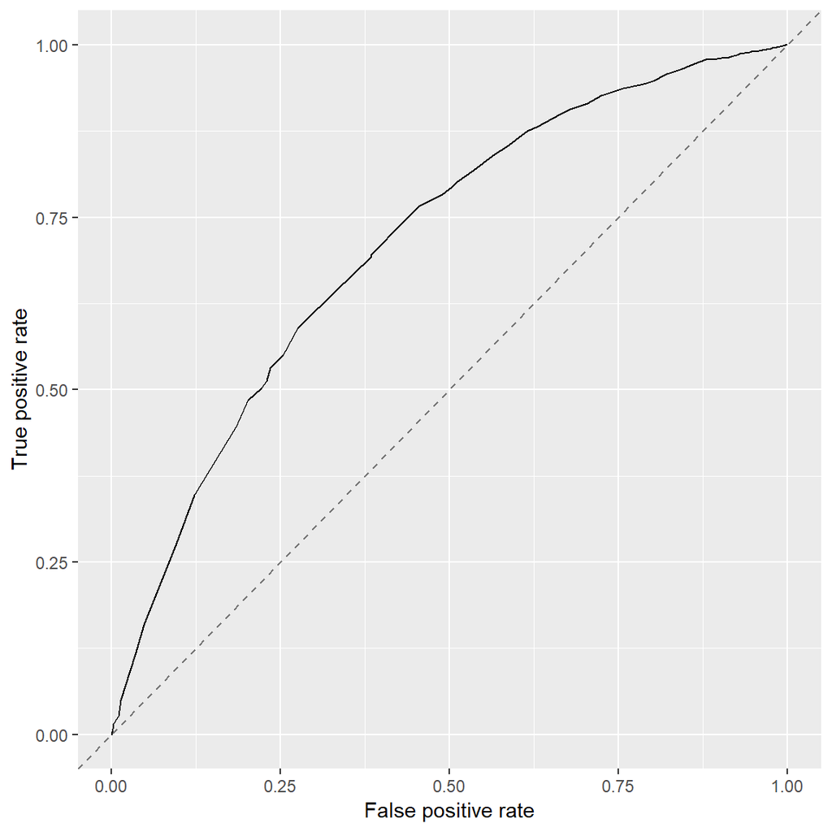

```r
classifTask <- makeClassifTask(data = tempTrain, target = "isRecid")
Lrn <- makeLearner("classif.ranger", predict.type = "prob")
r <- mlr::train(Lrn, classifTask)
results <- predict(r, newdata = tempTest)
temp <-  generateThreshVsPerfData(results, measures = list(fpr, tpr, mmce))
plotROCCurves(temp)
```

```r
performance(results, list(auc,acc))
```

```
##       auc       acc
## 0.7118422 0.6902703
```

Pomimo uzależnienia zmiennej celu od jedynie trzech kolumn wyjściowej ramki, uzyskaliśmy taką samą skuteczność z dokładnością do ustawionego ziarna.

# 4 Podsumowanie

- obecność `chargeDesc` pogarsza wyniki, a różne próby pogrupowania tej zmiennej nic nie wniosły
- dodane przez nas kolumny mają większą korelację z celem; pomogły nam ulepszyć model do średnio 0.73 auc
- dyskretyzacja kluczowych zmiennych nie pomaga
- kodowania impact encoding oraz dummy variables nie wprowadziły znaczących zmian
- tworzone przez kodowanie kolumny mogłyby pomóc przy tworzeniu modelu poprzez empiryczny wybór najbardziej istotnych kolumn ( do sprawdzenia, ale bardzo długo się liczy )
- z powyższego przykładu widać, że w zbiorze danych brakuje kluczowych zmiennych, aby klasyfikować zmienną `isRecid` na 0.70 auc wystarczą nam trzy kolumny
- większość z tych wyników i tak zależy od random seed